# Data Scraping with R

20 June 2017

## Welcome

A Quote from the charter:

“WG 33 supports methodologically sound work that will **advance the community’s analytic capabilities** for the complex and uncertain operating environments faced today.”"

## Today’s Overview

Digital Data Collection Techniques

- Traditional Collection
- Google Docs
- Data Scraping
- Super Data Scraping

## Acknowledgements

1. [COL Joe Lindquist](http://www.usma.edu/math/_layouts/wpFacultyBios/DisplayBio.aspx?ID=ebdd74e5-07fe-4bd0-b30d-ff96f904ce6e&List=1ebd54dc-d44d-4834-8add-2da90afb21f5)  
   Academy Professor  
   Mentor
2. [Jill Turner](https://www.facebook.com/jill.finkbeinerturner)  
   Wife  
   Biggest Fan

## ‘Old School’ Web Scraping

Lets look at some interesting [data](http://www.pro-football-reference.com/teams/dal/coaches.htm).

[figure not shown]

## ‘Newer School’ Web Scraping

[Google Docs](https://docs.google.com/spreadsheets/d/1o_2wPqMA0tlPzDnHVHZebtz6B3c_iu9ledWE0aouwMY/edit?usp=sharing)

## Problem of Extention

- Dallas Cowboys
- NY Giants
- Philadelphia Eagles
- Washington Redskins

[figure not shown]

## Enter R Vest

- Hadley Wickham
- [Github Repository](https://github.com/hadley?tab=repositories)
- Professional Webpage
- [@hadleywickham](https://twitter.com/hadleywickham)

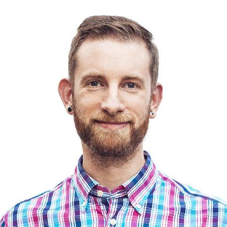

## R Vest How To

Install the package

```r
install.packages("rvest")
```

Call the package

```r
library(rvest)
```

## R Vest How To

R Vest Requires 3 Pieces of Information

1. URL
2. CSS or X Path Selector
3. Data Type

## R Vest How To

Using Our Dallas Cowboys Example

1. URL = “http://www.pro-football-reference.com/teams/dal/coaches.htm”
2. CSS or X Path Selector
3. Data Type

## R Vest How To

Using Our Dallas Cowboys Example

1. URL = http://www.pro-football-reference.com/teams/dal/coaches.htm
2. **CSS or X Path Selector**
3. Data Type

[figure not shown]

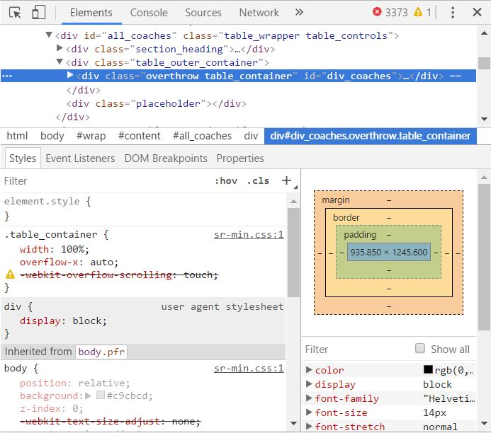

## R Vest How To

There’s got to be an easier way…

Enter Selector Gadget

[Selector Gadget Chrome Download](https://chrome.google.com/webstore/detail/selectorgadget/mhjhnkcfbdhnjickkkdbjoemdmbfginb?hl=en)

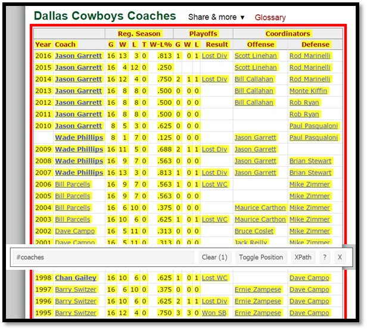

## R Vest How To

1. URL = “http://www.pro-football-reference.com/teams/dal/coaches.htm”
2. CSS or X Path Selector
3. **Data Type** Table or Text

## R Vest How To

Call Library

```r
## library(rvest)
```

Input URL

```r
## step1 = read_html("URL IN QUOTES")
```

CSS or X Path Selector

```r
## step2 = html_nodes(step1, xpath =, css = )
```

Scrape the Data

```r
## step3 = html_table(step2, header = TRUE)
```

## Dallas Cowboys Example: X Path

Input URL

```r
step1x = read_html("http://www.pro-football-reference.com/teams/dal/coaches.htm")
```

X Path ID

```r
step2x = html_nodes(step1x, xpath='//*[(@id = "coaches")]')
```

Scrape the Data

```r
step3x = html_table(step2x, header = TRUE)
```

View the data

```r
head(step3x[[1]][1:6])
```

```
##                   .1 Reg. Season Reg. Season.1 Reg. Season.2 Reg. Season.3
## 1 Year         Coach           G             W             L             T
## 2 2017 Jason Garrett          11             5             6             0
## 3 2016 Jason Garrett          16            13             3             0
## 4 2015 Jason Garrett          16             4            12             0
## 5 2014 Jason Garrett          16            12             4             0
## 6 2013 Jason Garrett          16             8             8             0
```

## Dallas Cowboys Example: CSS

Input URL

```r
step1css = read_html("http://www.pro-football-reference.com/teams/dal/coaches.htm")
```

CSS

```r
step2css = html_nodes(step1css, css="#coaches")
```

Scrape the Data

```r
step3css = html_table(step2css, header = TRUE)
```

View the data

```r
head(step3css[[1]][1:6])
```

```
##                   .1 Reg. Season Reg. Season.1 Reg. Season.2 Reg. Season.3
## 1 Year         Coach           G             W             L             T
## 2 2017 Jason Garrett          11             5             6             0
## 3 2016 Jason Garrett          16            13             3             0
## 4 2015 Jason Garrett          16             4            12             0
## 5 2014 Jason Garrett          16            12             4             0
## 6 2013 Jason Garrett          16             8             8             0
```

## Simplify: The Pipe Command

A Short Aside

```r
multiply = function(x,y) {
  answer = x * y
  return(answer)
}
multiply(3,4)
```

```
## [1] 12
```

```r
3 %>% multiply(4)
```

```
## [1] 12
```

## R Vest How To

```r
allonestep = "http://www.pro-football-reference.com/teams/dal/coaches.htm" %>%
    read_html() %>%
    html_nodes(xpath='//*[(@id = "coaches")]') %>%
    html_table(header = TRUE)
```

View the data

```r
allonestep=allonestep[[1]]
colnames(allonestep)=allonestep[1,]
head(allonestep[,1:12])
```

```
##   Year         Coach  G  W  L T W-L% G.1 W.1 L.1   Result       Offense
## 1 Year         Coach  G  W  L T W-L%   G   W   L   Result       Offense
## 2 2017 Jason Garrett 11  5  6 0 .455                      Scott Linehan
## 3 2016 Jason Garrett 16 13  3 0 .813   1   0   1 Lost Div Scott Linehan
## 4 2015 Jason Garrett 16  4 12 0 .250                      Scott Linehan
## 5 2014 Jason Garrett 16 12  4 0 .750   2   1   1 Lost Div Bill Callahan
## 6 2013 Jason Garrett 16  8  8 0 .500   0   0   0          Bill Callahan
```

## Other Examples: Stocks

[figure not shown]

```r
pandora = "http://www.nasdaq.com/symbol/p"

pstock = pandora %>%
  read_html() %>%
  html_nodes("#quotes_content_left_InfoQuotesResults td+ td") %>%
  html_text()
```

Downloading Stocks of Interest

```r
pstock
```

```
##  [1] "10.5"
##  [2] "$ 5.395 / $ 5.25"
##  [3] "\r\n                                        8,789,539\r\n                                    "
##  [4] "8,230,800"
##  [5] "$ 5.26"
##  [6] "\r\n                                        $ 14.10 / $ 4.44\r\n                                    "
##  [7] "$ 1,321,032,510 "
##  [8] "NE"
##  [9] "NE"
## [10] "$ -2.48"
## [11] "N/A"
## [12] "N/A"
## [13] "N/A"
## [14] "0 %"
## [15] "-0.72"
```

```r
pstock[5]
```

```
## [1] "$ 5.26"
```

Or time stamp the data

```r
pstock=(as.data.frame(pstock))
cbind(pstock,Sys.time())[5,]
```

```
##   pstock          Sys.time()
## 5 $ 5.26 2017-11-27 19:25:37
```

## Other Examples: NBA Basketball

[figure not shown]

## Other Examples: NBA Basketball

```r
nbaurl = "http://www.basketball-reference.com/leaders/g_career_p.html"

leaders = nbaurl %>%
  read_html() %>%
  html_nodes("#tot") %>%
  html_table()
```

See the Results

```r
leaders=as.data.frame(leaders)
head(leaders,20)
```

```
##    Rank               Player   G
## 1     1         Derek Fisher 259
## 2     2           Tim Duncan 251
## 3     3         Robert Horry 244
## 4     4 Kareem Abdul-Jabbar* 237
## 5     5          Tony Parker 221
## 6     6          Kobe Bryant 220
## 7     7         LeBron James 217
## 8     8    Shaquille O'Neal* 216
## 9     9        Manu Ginobili 213
## 10   10      Scottie Pippen* 208
## 11   11         Karl Malone* 193
## 12   NA          Danny Ainge 193
## 13   13       Magic Johnson* 190
## 14   14       Julius Erving* 189
## 15   15       Robert Parish* 184
## 16   16          Byron Scott 183
## 17   17       John Stockton* 182
## 18   18      Dennis Johnson* 180
## 19   19      Michael Jordan* 179
## 20   20      Rasheed Wallace 177
```

## Other Examples: World Factbook

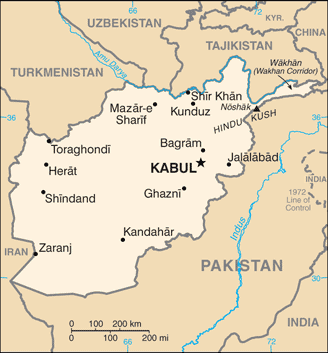

## Other Examples: World Factbook

```r
factbook <- "https://www.cia.gov/library/publications/the-world-factbook/geos/af.html"

areaaf <- factbook %>%
  read_html() %>%
  html_nodes(".even:nth-child(6) .category_data:nth-child(14) , .even:nth-child(6)
             #field:nth-child(13) a , #field+ div:nth-child(28) .category_data ,
             #field:nth-child(27) a , #field:nth-child(5)~ #field:nth-child(7) a ,
             .even:nth-child(4) div:nth-child(9) .category_data ,
             #field+ div:nth-child(8) .category_data , .countryName") %>%
html_text()
```

See the results

```r
areaaf
```

```
##  [1] "AFGHANISTAN"
##  [2] "AFGHANISTAN"
##  [3] "AFGHANISTAN"
##  [4] "AFGHANISTAN"
##  [5] "AFGHANISTAN"
##  [6] "Area:"
##  [7] ""
##  [8] "652,230 sq km"
##  [9] "AFGHANISTAN"
## [10] "Elevation:"
## [11] ""
## [12] "1,884 m"
## [13] "AFGHANISTAN"
## [14] "Citizenship:"
## [15] ""
## [16] "no"
## [17] "Electricity - from hydroelectric plants:"
## [18] ""
```

## Other Examples: University Info

[figure not shown]

```r
westpoint = "https://www.princetonreview.com/schools/1023919/college/united-states-military-academy"

wp = westpoint %>%
  read_html() %>%
  html_nodes("#admissions .col-sm-4 div") %>%
  html_text()
wp
```

```
##  [1] "Applicants"
##  [2] "14,829"
##  [3] "Acceptance Rate"
##  [4] "10%"
##  [5] "SAT Reading"
##  [6] "25th-75th percentile(enrolled students)"
##  [7] "580 - 690"
##  [8] "SAT Math"
##  [9] "25th-75th percentile(enrolled students)"
## [10] "600 - 700"
## [11] "SAT Writing"
## [12] "25th-75th percentile(enrolled students)"
## [13] "550 - 660"
```

```r
navy = "https://www.princetonreview.com/schools/1022813/college/united-states-naval-academy"

goats = navy %>%
  read_html() %>%
  html_nodes("#admissions .col-sm-4 div") %>%
  html_text()
goats
```

```
##  [1] "Applicants"
##  [2] "17,043"
##  [3] "Acceptance Rate"
##  [4] "8%"
##  [5] "Average HS GPA"
##  [6] "4.16"
##  [7] "\n        \n            79%\n        \n        \n            Over 3.75\n        \n    "
##  [8] "\n            79%\n        "
##  [9] "\n            Over 3.75\n        "
## [10] "\n        \n            10%\n        \n        \n            3.50 - 3.74\n        \n    "
## [11] "\n            10%\n        "
## [12] "\n            3.50 - 3.74\n        "
## [13] "\n        \n            6%\n        \n        \n            3.25 - 3.49\n        \n    "
## [14] "\n            6%\n        "
## [15] "\n            3.25 - 3.49\n        "
## [16] "\n        \n            4%\n        \n        \n            3.00 - 3.24\n        \n    "
## [17] "\n            4%\n        "
## [18] "\n            3.00 - 3.24\n        "
## [19] "\n        \n            1%\n        \n        \n            2.50 - 2.99\n        \n    "
## [20] "\n            1%\n        "
## [21] "\n            2.50 - 2.99\n        "
## [22] "SAT Reading"
## [23] "25th-75th percentile(enrolled students)"
## [24] "570 - 680"
## [25] "SAT Math"
## [26] "25th-75th percentile(enrolled students)"
## [27] "600 - 710"
```

```r
airforce = "https://www.princetonreview.com/schools/1023678/college/united-states-air-force-academy"

zoomie = airforce %>%
  read_html() %>%
  html_nodes("#admissions .col-sm-4 div") %>%
  html_text()
zoomie
```

```
##  [1] "Applicants"
##  [2] "9,894"
##  [3] "Acceptance Rate"
##  [4] "15%"
##  [5] "Average HS GPA"
##  [6] "3.87"
##  [7] "\n        \n            78%\n        \n        \n            Over 3.75\n        \n    "
##  [8] "\n            78%\n        "
##  [9] "\n            Over 3.75\n        "
## [10] "\n        \n            13%\n        \n        \n            3.50 - 3.74\n        \n    "
## [11] "\n            13%\n        "
## [12] "\n            3.50 - 3.74\n        "
## [13] "\n        \n            7%\n        \n        \n            3.25 - 3.49\n        \n    "
## [14] "\n            7%\n        "
## [15] "\n            3.25 - 3.49\n        "
## [16] "\n        \n            2%\n        \n        \n            3.00 - 3.24\n        \n    "
## [17] "\n            2%\n        "
## [18] "\n            3.00 - 3.24\n        "
## [19] "SAT Reading"
## [20] "25th-75th percentile(enrolled students)"
## [21] "600 - 690"
## [22] "SAT Math"
## [23] "25th-75th percentile(enrolled students)"
## [24] "620 - 720"
```

```r
aggregate = data.frame(School = c("Army", "Navy", "Air Force"),
                       Applicants = c(wp[2],goats[2],zoomie[2]),
                       AcceptanceRate = c(wp[4],goats[4],zoomie[4]))
aggregate
```

```
##      School Applicants AcceptanceRate
## 1      Army     14,829            10%
## 2      Navy     17,043             8%
## 3 Air Force      9,894            15%
```

## Super Scraping

```r
teamurls = c(NA)
teamabvs = c("nwe", "mia", "buf", "nyj", "pit", "rav", "cin", "cle", "htx", "oti",
             "clt", "jax", "rai", "kan", "den", "sdg", "dal", "nyg", "was", "phi",
             "det", "min", "gnb", "chi", "tam", "atl", "car", "nor", "sea", "crd",
             "ram", "sfo")
for (i in 1:length(teamabvs)) {
  teamurls[i] = paste0(paste0("http://www.pro-football-reference.com/teams/",
                              teamabvs[i]),"/coaches.htm")
}
head(teamurls,10)
```

```
##  [1] "http://www.pro-football-reference.com/teams/nwe/coaches.htm"
##  [2] "http://www.pro-football-reference.com/teams/mia/coaches.htm"
##  [3] "http://www.pro-football-reference.com/teams/buf/coaches.htm"
##  [4] "http://www.pro-football-reference.com/teams/nyj/coaches.htm"
##  [5] "http://www.pro-football-reference.com/teams/pit/coaches.htm"
##  [6] "http://www.pro-football-reference.com/teams/rav/coaches.htm"
##  [7] "http://www.pro-football-reference.com/teams/cin/coaches.htm"
##  [8] "http://www.pro-football-reference.com/teams/cle/coaches.htm"
##  [9] "http://www.pro-football-reference.com/teams/htx/coaches.htm"
## [10] "http://www.pro-football-reference.com/teams/oti/coaches.htm"
```

Call Library

```r
library(dplyr)
```

Scrape data and build table

```r
coaches = data.frame(NA)
for (i in 1:length(teamurls)) {
  allonestep = teamurls[i] %>%
    read_html() %>%
    html_nodes(xpath='//*[(@id = "coaches")]') %>%
    html_table(header = FALSE)
  allonestep <- allonestep[[1]]
  allonestep = allonestep[-1,]
  coaches = bind_rows(coaches, allonestep)
}
```

```r
coaches
```

```
##      NA.   X1                     X2   X3   X4   X5   X6    X7   X8   X9
## 1     NA <NA>                   <NA> <NA> <NA> <NA> <NA>  <NA> <NA> <NA>
## 2     NA Year                  Coach    G    W    L    T  W-L%    G    W
## 3     NA 2017         Bill Belichick   11    9    2    0  .818
## 4     NA 2016         Bill Belichick   16   14    2    0  .875    3    3
## 5     NA 2015         Bill Belichick   16   12    4    0  .750    2    1
## 6     NA 2014         Bill Belichick   16   12    4    0  .750    3    3
## 7     NA 2013         Bill Belichick   16   12    4    0  .750    2    1
## 8     NA 2012         Bill Belichick   16   12    4    0  .750    2    1
## 9     NA 2011         Bill Belichick   16   13    3    0  .813    3    2
## 10    NA 2010         Bill Belichick   16   14    2    0  .875    1    0
## 11    NA 2009         Bill Belichick   16   10    6    0  .625    1    0
## 12    NA 2008         Bill Belichick   16   11    5    0  .688    0    0
## 13    NA 2007         Bill Belichick   16   16    0    0 1.000    3    2
## 14    NA 2006         Bill Belichick   16   12    4    0  .750    3    2
```

[output cut: 6342 more lines]

Data Cleaning

```r
coaches = coaches[-1,]
coaches = coaches[,-1]
coaches = coaches[,-(12:13)]
title = coaches[c(1),]
colnames(coaches) = title
coaches = coaches[-1,]
coaches$censor = ifelse(coaches$Year==2016,1,0)
colnames(coaches) = c("Year","Coach","Games","Wins","Losses","Ties","Record","PG",
                      "PW","PT","Result", "censor")
coaches$Year = as.numeric(coaches$Year)
coaches$Games = as.numeric(coaches$Games)
coaches$Wins = as.numeric(coaches$Wins)
coaches$Losses= as.numeric(coaches$Losses)
coaches$Ties= as.numeric(coaches$Ties)
coaches$Record= as.numeric(coaches$Record)
coaches$PG = as.numeric(coaches$PG)
coaches$PW = as.numeric(coaches$PW)
coaches$PT= as.numeric(coaches$PT)
coaches$censor= as.numeric(coaches$censor)
attach(coaches)
coaches2 = aggregate(cbind(Games, Wins, Losses, Ties, PG, PW, PT, censor) ~
                       Coach, coaches, sum)
yearcoached = count(coaches, vars = Coach)
yearcoached = as.data.frame(yearcoached)
colnames(yearcoached) = c("Coach", "n")
coaches2 = left_join(coaches2, yearcoached)
attach(coaches2)
coaches2
```

```
##                      Coach Games Wins Losses Ties PG PW PT censor  n
## 1             Aaron Kromer     6    2      4    0  0  0  0      0  1
## 2               Abe Gibron    42   11     30    1  0  0  0      0  3
## 3                Adam Gase    16   10      6    0  1  0  1      1  2
## 4               Adam Walsh    21   15      5    1  1  1  0      0  2
## 5                 Al Davis    42   23     16    3  0  0  0      0  3
## 6                  Al Groh    16    9      7    0  0  0  0      0  1
## 7              Al Saunders    39   17     22    0  0  0  0      0  3
## 8             Aldo Donelli    15    4     11    0  0  0  0      0  2
## 9             Alex Webster    70   29     40    1  0  0  0      0  5
## 10           Allie Sherman   112   57     51    4  3  0  3      0  8
## 11               Andy Reid   288  173    114    1 23 11 12      1 19
## 12            Anthony Lynn     1    0      1    0  0  0  0      1  2
## 13           Arnie Horween    22   13      8    1  0  0  0      0  2
## 14               Art Lewis     8    4      4    0  0  0  0      0  1
```

[output cut: 345 more lines]

Survival Analysis

```r
library(survival)
```

```r
my.surv.object <- Surv(n, censor)
### creates survival analysis model
firedmodel = coxph(my.surv.object~Wins+Games+Losses+PG+PW)
```

```r
summary(firedmodel)
```

```
## Call:
## coxph(formula = my.surv.object ~ Wins + Games + Losses + PG +
##     PW)
##
##   n= 359, number of events= 13
##
##           coef exp(coef) se(coef)      z Pr(>|z|)
## Wins    1.0031    2.7268   0.6674  1.503    0.133
## Games  -1.0804    0.3395   0.6641 -1.627    0.104
## Losses  0.9450    2.5729   0.6621  1.427    0.154
## PG      0.6419    1.9001   0.4541  1.414    0.157
## PW     -0.5128    0.5988   0.5041 -1.017    0.309
##
##        exp(coef) exp(-coef) lower .95 upper .95
## Wins      2.7268     0.3667   0.73722    10.086
## Games     0.3395     2.9457   0.09237     1.248
## Losses    2.5729     0.3887   0.70274     9.420
## PG        1.9001     0.5263   0.78026     4.627
## PW        0.5988     1.6699   0.22297     1.608
##
## Concordance= 0.987  (se = 0.105 )
## Rsquare= 0.162   (max possible= 0.274 )
## Likelihood ratio test= 63.6  on 5 df,   p=2.189e-12
## Wald test            = 23.13  on 5 df,   p=0.0003187
## Score (logrank) test = 26.74  on 5 df,   p=6.411e-05
```

Make a Prediction

```r
ndata = data.frame(Wins= 5, Games= 6, Losses = 1, PG=0, PW = 0)
predict(firedmodel, newdata = ndata, type=c("lp", "risk", "expected", "terms", "survival"))
```

```
##      1
## 7.7194
```

## Other Scraping Examples

Sentament Analysis

Model Building Pseudo Code

```r
# for(i in 1:nrow(buildURLs)){
#   urls[i] = paste0("http://transcripts.cnn.com/TRANSCRIPTS/", year[i]),
#   month[i]),"/"),day[i]),"/acd.0"),
# }
#
# for(i in 1:length(urls)){
#   cnn <- urls[i] %>%
#   read_html() %>%
#   html_nodes(".cnnBodyText")
# }
```

## Other Scraping Examples

Anderson Cooper

```r
cnn
```

```
##         X    x            y year month day yearcount monthactual alt
## 1       1   11 -0.322175732    5     1  11        11         Jan   1
## 2       2   13 -0.395299145    5     1  13        13         Jan   1
## 3       3   17 -0.413793103    5     1  17        17         Jan   1
## 4       4   21 -0.358757062    5     1  21        21         Jan   1
## 5       5   25 -0.309686221    5     1  25        25         Jan   1
## 6       6   31 -0.312762973    5     1  31        31         Jan   1
## 7       7   41 -0.306799337    5     2  10        41         Feb   1
## 8       8   45 -0.284578696    5     2  14        45         Feb   1
## 9       9   47 -0.421511628    5     2  16        47         Feb   1
## 10     10   49 -0.489566613    5     2  18        49         Feb   1
## 11     11   53 -0.343835616    5     2  22        53         Feb   1
## 12     12   55 -0.362126246    5     2  24        55         Feb   1
## 13     13   59 -0.437819421    5     2  28        59         Feb   1
## 14     14   73 -0.423622047    5     3  11        73         Mar   1
```

[output cut: 3696 more lines]

## Other Scraping Examples

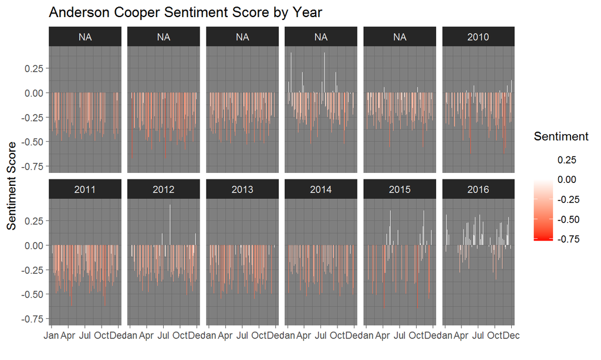

## Terms of Service

**“We have seen an uptick in requests from students, academics and businesses looking to receive custom datasets from our sites, in some cases for free and in some cases for a small fee.”**

“These requests occur multiple times a week and sometimes multiple times per day. These requests take a considerable amount of time… Generally we’ve only been asking for coverage of our time… However, the rate of requests has forced us to reevaluate this stance.”

“As an aside, copyright law is clear that **facts cannot be copyrighted**, so you are free to reuse facts found on this site in accordance with copyright laws.”

“Moving forward, our data request policy is as follows:

“We will not fulfill any requests for data for custom downloads, unless you are prepared to pay a minimum of $1,000 for any such request.”

## Then The Truth…

“We realize this will be insurmountable for any student requests. **However, I would point out that learning how to accumulate data is often a more valuable skill than actually analyzing the data**, so we encourage you as a student or professional to learn how. We also realize that your request may not take that long by itself, but when coupled with everyone else’s requests it becomes a significant expense for us.”

[Sports Refrence Terms of Service](http://www.sports-reference.com/data_use.html)

## Final Acknowlegements

[@hadleywickham](https://twitter.com/hadleywickham)  
[Selector Gadget Chrome Download](https://chrome.google.com/webstore/detail/selectorgadget/mhjhnkcfbdhnjickkkdbjoemdmbfginb?hl=en)  
[Bet Labs Sports](https://www.betlabssports.com/)  
[Pro Football Refrence](http://www.pro-football-reference.com/teams/dal/coaches.htm)  
[Pro Basketball Refrence](http://www.basketball-reference.com/leaders/g_career_p.html)  
[NASDAQ Website](http://www.nasdaq.com/symbol/p)  
[World Factbook](https://www.cia.gov/library/publications/the-world-factbook/geos/af.html)  
[Princeton Review](https://www.princetonreview.com/schools/1023919/college/united-states-military-academy)